# Arbeidskrav 2, interference

Ingvild Kåshagen

20 10 2020

## R Markdown

### Innledning og hypotese:

I denne oppgaven skal vi se på hvorvidt en treningsintervensjon påvirker totalt RNA innhold i muskelen, og om denne påvirkningen er forskjellig fra personer som defineres som “high” eller “low” responders på treningsintervensjonen.

Hypotese: Trening effekten påvirker total mengde RNA mer i gruppen “high responders” enn i gruppen “low responders”, etter en treningsperiode. 0 hypotese: det er ingen forskjell mellom gruppene For å gjøre dette ønsker vi å gjøre følgende:

Vi har her gjort følgende: 1. Laste inn aktuelle pakker. 2. Laste ned datasett og plukke ut aktuelle variabler i forhold til problemstillingen. 3. T. test- er det sannsynlig at hypotesen stemmer? 4. Gjøre om til boxplot 5. Konklusjon

### Installere pakker

```r
library(readxl)
library (tidyverse)
```

### Laste ned datasett fra Haun (2019)- hypertrophy.

```r
download.file(url = "https://ndownloader.figstatic.com/files/14702420", destfile = "hypertrophy.csv")
```

### Lese datasett og lage ny variabel.

```r
hypertrophy1 <- read_csv("hypertrophy.csv")
```

### På neste steg vil vi velge ut aktuelle vairabler i forhold til problemstillingen. T3T1_PERCENT_CHANGE_RNA variabelen representerer den prosentvise endringen i total RNA mengde i muskelen fra begynnelsen til slutten av treningsintervensjonen. SUB_ID representerer subjektene, Cluster variabelen differensierer mellom gruppene high og low responders.

```r
hyp2 <- hypertrophy1 %>%
  select(SUB_ID, CLUSTER, T1_RNA, T3_RNA) %>%
  print()
```

```
## # A tibble: 30 x 4
##    SUB_ID CLUSTER T1_RNA T3_RNA
##    <chr>  <chr>    <dbl>  <dbl>
##  1 MRV001 LOW       314.   589.
##  2 MRV002 HIGH      338.   466.
##  3 MRV003 HIGH      372.   509.
##  4 MRV004 LOW       322.   556.
##  5 MRV005 HIGH      334    354.
##  6 MRV006 LOW       318.   387.
##  7 MRV007 <NA>      343.   397.
##  8 MRV009 <NA>      382.   390.
##  9 MRV010 <NA>      419.   509.
## 10 MRV011 HIGH      334.   428.
## # … with 20 more rows
```

### Velger ut data og fjerner NA

Her bruker vi gjennomsnittsscore, unngår å konvertere til prosent for å sammenligne grupper. Fjerner NA fra cluster variabel.

```r
hyp3 <- hypertrophy1 %>%
  select(SUB_ID, CLUSTER, T3T1__RNA) %>%
  filter(!is.na(CLUSTER)) %>%
  print()
```

```
## # A tibble: 20 x 3
##    SUB_ID CLUSTER T3T1__RNA
##    <chr>  <chr>       <dbl>
##  1 MRV001 LOW         276.
##  2 MRV002 HIGH        128.
##  3 MRV003 HIGH        137.
##  4 MRV004 LOW         234.
##  5 MRV005 HIGH         19.8
##  6 MRV006 LOW          69.8
##  7 MRV011 HIGH         93.7
##  8 MRV012 HIGH         -2.9
##  9 MRV013 LOW         163.
## 10 MRV016 LOW         140.
## 11 MRV019 HIGH        -39.3
## 12 MRV021 HIGH        172.
## 13 MRV024 LOW          52.1
## 14 MRV030 LOW           0.4
## 15 MRV032 LOW          83.1
## 16 MRV033 LOW          50.4
## 17 MRV034 HIGH        -74.9
## 18 MRV035 HIGH         66
## 19 MRV036 HIGH        166
## 20 MRV038 LOW         158.
```

### Welch Wwo sample T-test

Her forklares variabelen T3T1_RNA gruppert for variabelen Cluster.

```r
t.test(T3T1__RNA  ~ CLUSTER, data = hyp3)
```

```
##
##  Welch Two Sample t-test
##
## data:  T3T1__RNA by CLUSTER
## t = -1.4366, df = 18, p-value = 0.168
## alternative hypothesis: true difference in means is not equal to 0
## 95 percent confidence interval:
##  -138.0434   25.9234
## sample estimates:
## mean in group HIGH  mean in group LOW
##              66.51             122.57
```

I denne Welch two sample T-testen ser vi at gjennomsnittet i LOW gruppen er noe høyere enn i HIGH gruppen. P- verdien er relativt høy, 0,168, noe som indikerer at det er en uønsket høy sannsynlighet for at resultatene er tilfeldige (vi ser helst at P- verdi er under 0,05).

### Boxplot

Lager diagram med variabelen T3T1_RNA gruppert for variabelen Cluster.

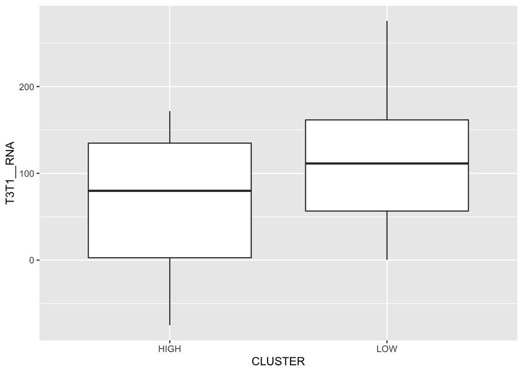

```r
hyp3 %>%
  ggplot(aes(CLUSTER, T3T1__RNA)) + geom_boxplot()
```

### Konklusjon

Den gjennomsnittlige økningen i Low gruppen er i resultatene litt høyere enn resultatene i High gruppen. Vi har en P- verdi som ligger på 0,168, noe som indikerer at det er en uønsket høy sannsynlighet for at resultatene er tilfeldige. Hypotesen kan dermed ikke bekreftes av dataene.